# Data Management

Center for Adolescent Health

25 June, 2021

# Content

1. Vanguard
2. HEYBMORE
3. Comparison of Vanguard and HEYBMORE
4. Comparison of Vanguard and HEYBMORE, similar age (18)

## 1. Vanguard

*Assessing Adolescents’ Access to Food Assistance Programs during COVID-19 Pandemic - Adolescent Food Insecurity*

### Food Security Graphs

“The next set of questions will ask you about food in your household.  
How often…”

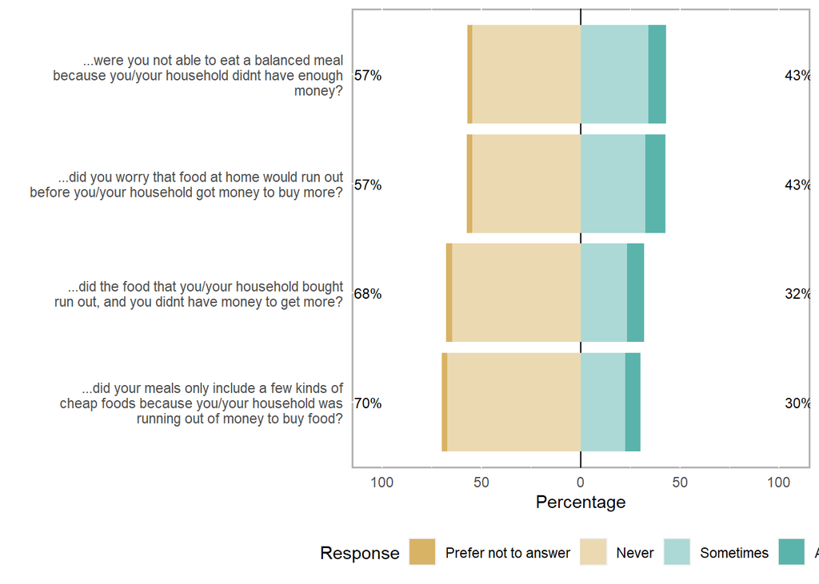

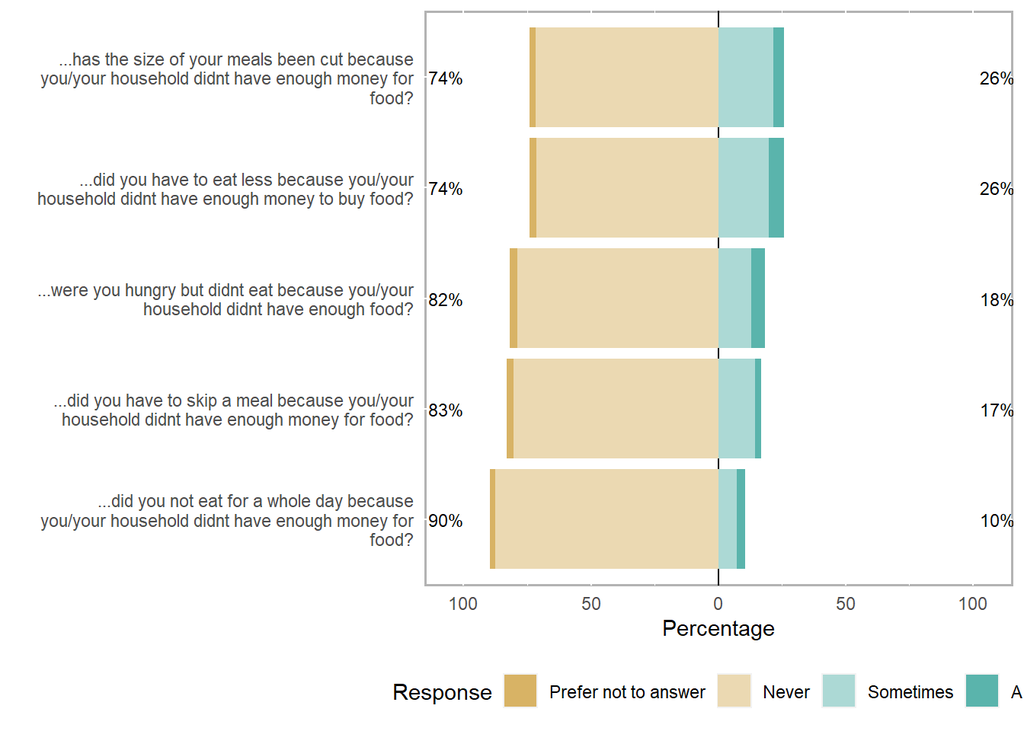

Vanguard Survey – Food Security Questions, by SNAP variable  
“The next set of questions will ask you about food in your household.  
**How often…”**

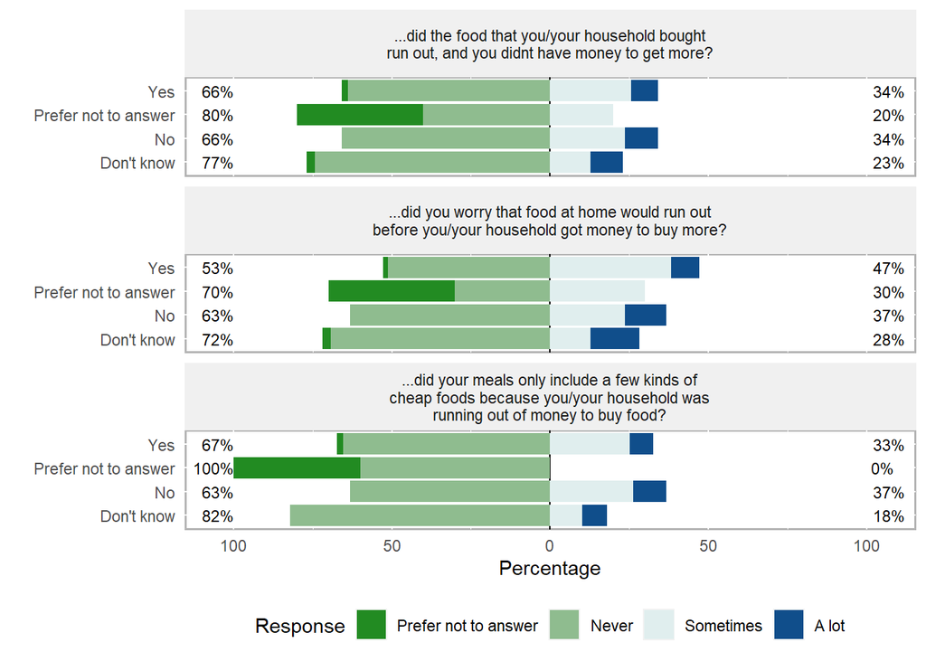

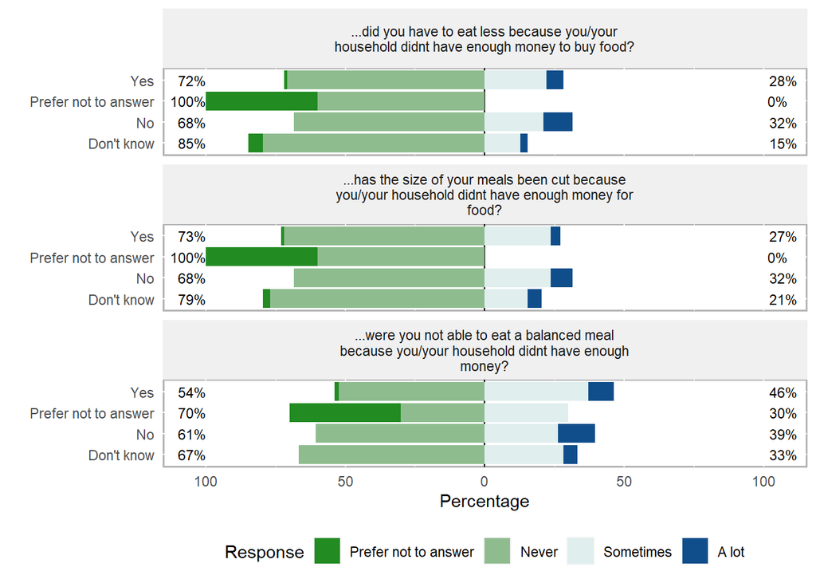

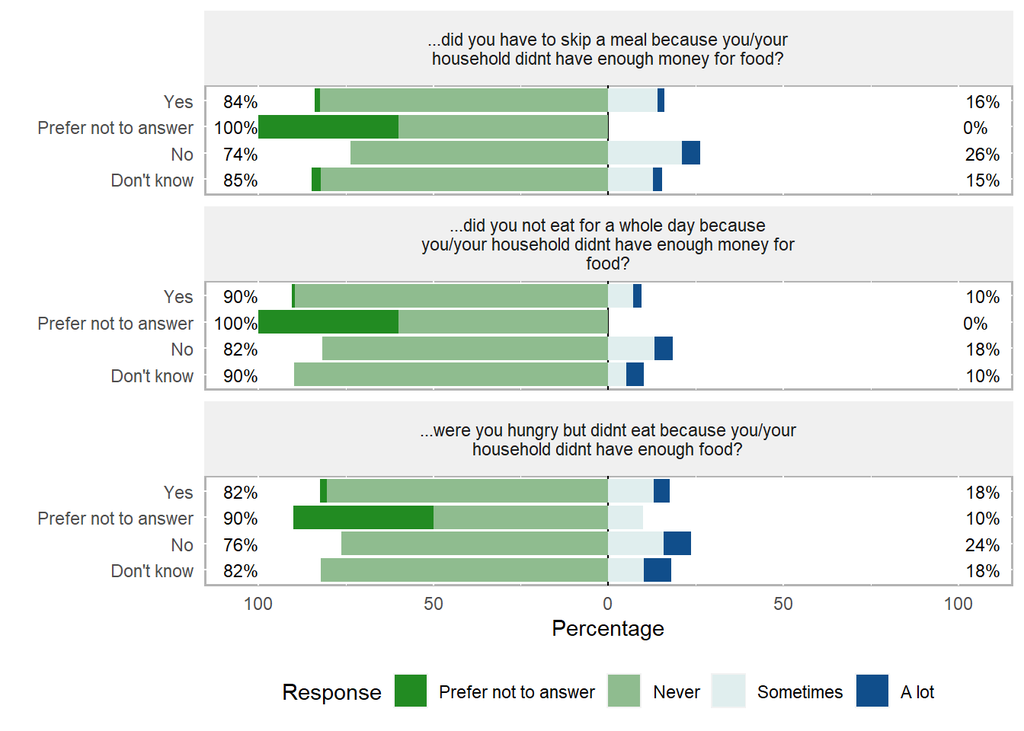

### Food Security Tables

Cross Tab - Vanguard, SNAP and Food Flag

```
##
##
##    Cell Contents
## |-------------------------|
## |                       N |
## |           N / Row Total |
## |-------------------------|
##
##
## Total Observations in Table:  286
##
##
##                      | Food Flag, >=2 (max: 18
##                 SNAP |  Moderate |      None | Row Total |
## ---------------------|-----------|-----------|-----------|
##           Don't know |        16 |        23 |        39 |
##                      |      0.41 |      0.59 |      0.14 |
## ---------------------|-----------|-----------|-----------|
##                   No |        17 |        21 |        38 |
##                      |      0.45 |      0.55 |      0.13 |
## ---------------------|-----------|-----------|-----------|
## Prefer not to answer |         7 |         3 |        10 |
##                      |      0.70 |      0.30 |      0.03 |
## ---------------------|-----------|-----------|-----------|
##                  Yes |       107 |        92 |       199 |
##                      |      0.54 |      0.46 |      0.70 |
## ---------------------|-----------|-----------|-----------|
##         Column Total |       147 |       139 |       286 |
## ---------------------|-----------|-----------|-----------|
##
##
```

Food security Questions

“The next set of questions will ask you about food in your household.  
How often…”

**“…did you worry that food at home would run out before you/your household got money to buy more?”**

| snap | Prefer not to answer | Never | Sometimes | A lot | Total |
| --- | --- | --- | --- | --- | --- |
| Don’t know | 1 (1.3%) | 27 (34.6%) | 5 (6.4%) | 6 (7.7%) | 39 (50.0%) |
| No | 0 (0.0%) | 24 (31.6%) | 9 (11.8%) | 5 (6.6%) | 38 (50.0%) |
| Prefer not to answer | 4 (20.0%) | 3 (15.0%) | 3 (15.0%) | 0 (0.0%) | 10 (50.0%) |
| Yes | 3 (0.8%) | 102 (25.6%) | 76 (19.1%) | 18 (4.5%) | 199 (50.0%) |
| Total | 8 (1.4%) | 156 (27.3%) | 93 (16.3%) | 29 (5.1%) | 286 (50.0%) |

**“…did the food that you/your household bought run out, and you didnt have money to get more?”**

| snap | Prefer not to answer | Never | Sometimes | A lot | Total |
| --- | --- | --- | --- | --- | --- |
| Don’t know | 1 (1.3%) | 29 (37.2%) | 5 (6.4%) | 4 (5.1%) | 39 (50.0%) |
| No | 0 (0.0%) | 25 (32.9%) | 9 (11.8%) | 4 (5.3%) | 38 (50.0%) |
| Prefer not to answer | 4 (20.0%) | 4 (20.0%) | 2 (10.0%) | 0 (0.0%) | 10 (50.0%) |
| Yes | 4 (1.0%) | 127 (31.9%) | 51 (12.8%) | 17 (4.3%) | 199 (50.0%) |
| Total | 9 (1.6%) | 185 (32.3%) | 67 (11.7%) | 25 (4.4%) | 286 (50.0%) |

**“…did your meals only include a few kinds of cheap foods because you/your household was running out of money to buy food?”**

| snap | Prefer not to answer | Never | Sometimes | A lot | Total |
| --- | --- | --- | --- | --- | --- |
| Don’t know | 0 (0.0%) | 32 (41.0%) | 4 (5.1%) | 3 (3.8%) | 39 (50.0%) |
| No | 0 (0.0%) | 24 (31.6%) | 10 (13.2%) | 4 (5.3%) | 38 (50.0%) |
| Prefer not to answer | 4 (20.0%) | 6 (30.0%) | 0 (0.0%) | 0 (0.0%) | 10 (50.0%) |
| Yes | 4 (1.0%) | 130 (32.7%) | 50 (12.6%) | 15 (3.8%) | 199 (50.0%) |
| Total | 8 (1.4%) | 192 (33.6%) | 64 (11.2%) | 22 (3.8%) | 286 (50.0%) |

**“…were you not able to eat a balanced meal because you/your household didnt have enough money?”**

| snap | Prefer not to answer | Never | Sometimes | A lot | Total |
| --- | --- | --- | --- | --- | --- |
| Don’t know | 0 (0.0%) | 26 (33.3%) | 11 (14.1%) | 2 (2.6%) | 39 (50.0%) |
| No | 0 (0.0%) | 23 (30.3%) | 10 (13.2%) | 5 (6.6%) | 38 (50.0%) |
| Prefer not to answer | 4 (20.0%) | 3 (15.0%) | 3 (15.0%) | 0 (0.0%) | 10 (50.0%) |
| Yes | 3 (0.8%) | 104 (26.1%) | 74 (18.6%) | 18 (4.5%) | 199 (50.0%) |
| Total | 7 (1.2%) | 156 (27.3%) | 98 (17.1%) | 25 (4.4%) | 286 (50.0%) |

**“…did you have to eat less because you/your household didnt have enough money to buy food?”**

| snap | Prefer not to answer | Never | Sometimes | A lot | Total |
| --- | --- | --- | --- | --- | --- |
| Don’t know | 2 (2.6%) | 31 (39.7%) | 5 (6.4%) | 1 (1.3%) | 39 (50.0%) |
| No | 0 (0.0%) | 26 (34.2%) | 8 (10.5%) | 4 (5.3%) | 38 (50.0%) |
| Prefer not to answer | 4 (20.0%) | 6 (30.0%) | 0 (0.0%) | 0 (0.0%) | 10 (50.0%) |
| Yes | 2 (0.5%) | 141 (35.4%) | 44 (11.1%) | 12 (3.0%) | 199 (50.0%) |
| Total | 8 (1.4%) | 204 (35.7%) | 57 (10.0%) | 17 (3.0%) | 286 (50.0%) |

**“…has the size of your meals been cut because you/your household didnt have enough money for food?”**

| snap | Prefer not to answer | Never | Sometimes | A lot | Total |
| --- | --- | --- | --- | --- | --- |
| Don’t know | 1 (1.3%) | 30 (38.5%) | 6 (7.7%) | 2 (2.6%) | 39 (50.0%) |
| No | 0 (0.0%) | 26 (34.2%) | 9 (11.8%) | 3 (3.9%) | 38 (50.0%) |
| Prefer not to answer | 4 (20.0%) | 6 (30.0%) | 0 (0.0%) | 0 (0.0%) | 10 (50.0%) |
| Yes | 2 (0.5%) | 143 (35.9%) | 47 (11.8%) | 7 (1.8%) | 199 (50.0%) |
| Total | 7 (1.2%) | 205 (35.8%) | 62 (10.8%) | 12 (2.1%) | 286 (50.0%) |

**“…did you have to skip a meal because you/your household didnt have enough money for food?”**

| snap | Prefer not to answer | Never | Sometimes | A lot | Total |
| --- | --- | --- | --- | --- | --- |
| Don’t know | 1 (1.3%) | 32 (41.0%) | 5 (6.4%) | 1 (1.3%) | 39 (50.0%) |
| No | 0 (0.0%) | 28 (36.8%) | 8 (10.5%) | 2 (2.6%) | 38 (50.0%) |
| Prefer not to answer | 4 (20.0%) | 6 (30.0%) | 0 (0.0%) | 0 (0.0%) | 10 (50.0%) |
| Yes | 3 (0.8%) | 164 (41.2%) | 28 (7.0%) | 4 (1.0%) | 199 (50.0%) |
| Total | 8 (1.4%) | 230 (40.2%) | 41 (7.2%) | 7 (1.2%) | 286 (50.0%) |

**“…were you hungry but didnt eat because you/your household didnt have enough food?”**

| snap | Prefer not to answer | Never | Sometimes | A lot | Total |
| --- | --- | --- | --- | --- | --- |
| Don’t know | 0 (0.0%) | 32 (41.0%) | 4 (5.1%) | 3 (3.8%) | 39 (50.0%) |
| No | 0 (0.0%) | 29 (38.2%) | 6 (7.9%) | 3 (3.9%) | 38 (50.0%) |
| Prefer not to answer | 4 (20.0%) | 5 (25.0%) | 1 (5.0%) | 0 (0.0%) | 10 (50.0%) |
| Yes | 4 (1.0%) | 160 (40.2%) | 26 (6.5%) | 9 (2.3%) | 199 (50.0%) |
| Total | 8 (1.4%) | 226 (39.5%) | 37 (6.5%) | 15 (2.6%) | 286 (50.0%) |

**“…did you not eat for a whole day because you/your household didnt have enough money for food?”**

| snap | Prefer not to answer | Never | Sometimes | A lot | Total |
| --- | --- | --- | --- | --- | --- |
| Don’t know | 0 (0.0%) | 35 (44.9%) | 2 (2.6%) | 2 (2.6%) | 39 (50.0%) |
| No | 0 (0.0%) | 31 (40.8%) | 5 (6.6%) | 2 (2.6%) | 38 (50.0%) |
| Prefer not to answer | 4 (20.0%) | 6 (30.0%) | 0 (0.0%) | 0 (0.0%) | 10 (50.0%) |
| Yes | 2 (0.5%) | 178 (44.7%) | 14 (3.5%) | 5 (1.3%) | 199 (50.0%) |
| Total | 6 (1.0%) | 250 (43.7%) | 21 (3.7%) | 9 (1.6%) | 286 (50.0%) |

### Anxiety Graphs

Vanguard Survey – Anxiety Questions  
“Please answer the following questions based on how you felt in the past 7 days.”

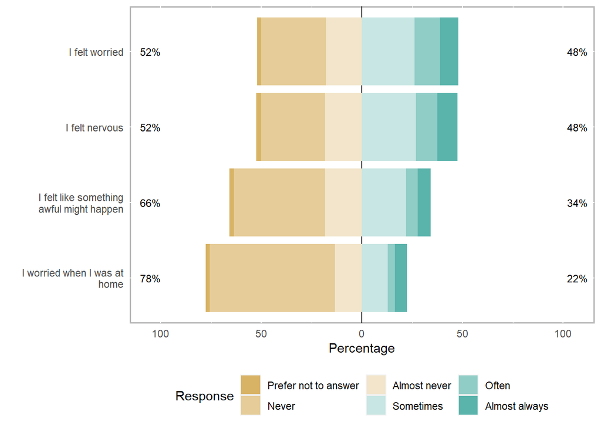

Vanguard Survey – Anxiety Questions, by SNAP variable  
“Please answer the following questions based on how you felt in the past 7 days.”

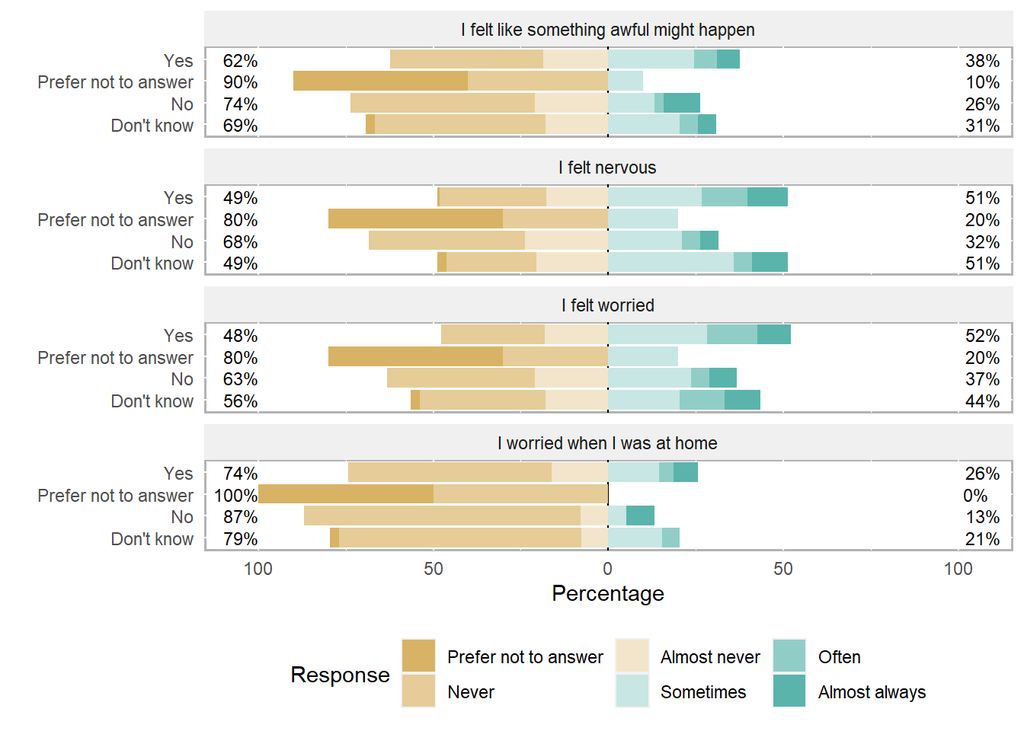

### Anxiety Tables

Cross Tab - Vanguard, SNAP and ANXIETY Flag

```
##
##
##    Cell Contents
## |-------------------------|
## |                       N |
## |           N / Row Total |
## |-------------------------|
##
##
## Total Observations in Table:  286
##
##
##                      | ANXIETY Flag, >=8 (max: 16)
##                 SNAP |         0 |         1 | Row Total |
## ---------------------|-----------|-----------|-----------|
##           Don't know |        28 |        11 |        39 |
##                      |      0.72 |      0.28 |      0.14 |
## ---------------------|-----------|-----------|-----------|
##                   No |        31 |         7 |        38 |
##                      |      0.82 |      0.18 |      0.13 |
## ---------------------|-----------|-----------|-----------|
## Prefer not to answer |         5 |         5 |        10 |
##                      |      0.50 |      0.50 |      0.03 |
## ---------------------|-----------|-----------|-----------|
##                  Yes |       146 |        53 |       199 |
##                      |      0.73 |      0.27 |      0.70 |
## ---------------------|-----------|-----------|-----------|
##         Column Total |       210 |        76 |       286 |
## ---------------------|-----------|-----------|-----------|
##
##
```

**“I felt like something awful might happen”**

| snap | Prefer not to answer | Never | Almost never | Sometimes | Often | Almost always | Total |
| --- | --- | --- | --- | --- | --- | --- | --- |
| Don’t know | 1 (1.3%) | 19 (24.4%) | 7 (9.0%) | 8 (10.3%) | 2 (2.6%) | 2 (2.6%) | 39 (50.0%) |
| No | 0 (0.0%) | 20 (26.3%) | 8 (10.5%) | 5 (6.6%) | 1 (1.3%) | 4 (5.3%) | 38 (50.0%) |
| Prefer not to answer | 5 (25.0%) | 4 (20.0%) | 0 (0.0%) | 1 (5.0%) | 0 (0.0%) | 0 (0.0%) | 10 (50.0%) |
| Yes | 0 (0.0%) | 87 (21.9%) | 37 (9.3%) | 49 (12.3%) | 13 (3.3%) | 13 (3.3%) | 199 (50.0%) |
| Total | 6 (1.0%) | 130 (22.7%) | 52 (9.1%) | 63 (11.0%) | 16 (2.8%) | 19 (3.3%) | 286 (50.0%) |

**“I felt nervous”**

| snap | Prefer not to answer | Never | Almost never | Sometimes | Often | Almost always | Total |
| --- | --- | --- | --- | --- | --- | --- | --- |
| Don’t know | 1 (1.3%) | 10 (12.8%) | 8 (10.3%) | 14 (17.9%) | 2 (2.6%) | 4 (5.1%) | 39 (50.0%) |
| No | 0 (0.0%) | 17 (22.4%) | 9 (11.8%) | 8 (10.5%) | 2 (2.6%) | 2 (2.6%) | 38 (50.0%) |
| Prefer not to answer | 5 (25.0%) | 3 (15.0%) | 0 (0.0%) | 2 (10.0%) | 0 (0.0%) | 0 (0.0%) | 10 (50.0%) |
| Yes | 1 (0.3%) | 61 (15.3%) | 35 (8.8%) | 53 (13.3%) | 26 (6.5%) | 23 (5.8%) | 199 (50.0%) |
| Total | 7 (1.2%) | 91 (15.9%) | 52 (9.1%) | 77 (13.5%) | 30 (5.2%) | 29 (5.1%) | 286 (50.0%) |

**“I felt worried”**

| snap | Prefer not to answer | Never | Almost never | Sometimes | Often | Almost always | Total |
| --- | --- | --- | --- | --- | --- | --- | --- |
| Don’t know | 1 (1.3%) | 14 (17.9%) | 7 (9.0%) | 8 (10.3%) | 5 (6.4%) | 4 (5.1%) | 39 (50.0%) |
| No | 0 (0.0%) | 16 (21.1%) | 8 (10.5%) | 9 (11.8%) | 2 (2.6%) | 3 (3.9%) | 38 (50.0%) |
| Prefer not to answer | 5 (25.0%) | 3 (15.0%) | 0 (0.0%) | 2 (10.0%) | 0 (0.0%) | 0 (0.0%) | 10 (50.0%) |
| Yes | 0 (0.0%) | 59 (14.8%) | 36 (9.0%) | 56 (14.1%) | 29 (7.3%) | 19 (4.8%) | 199 (50.0%) |
| Total | 6 (1.0%) | 92 (16.1%) | 51 (8.9%) | 75 (13.1%) | 36 (6.3%) | 26 (4.5%) | 286 (50.0%) |

**“I worried when I was at home”**

| snap | Prefer not to answer | Never | Almost never | Sometimes | Often | Almost always | Total |
| --- | --- | --- | --- | --- | --- | --- | --- |
| Don’t know | 1 (1.3%) | 27 (34.6%) | 3 (3.8%) | 6 (7.7%) | 2 (2.6%) | 0 (0.0%) | 39 (50.0%) |
| No | 0 (0.0%) | 30 (39.5%) | 3 (3.9%) | 2 (2.6%) | 0 (0.0%) | 3 (3.9%) | 38 (50.0%) |
| Prefer not to answer | 5 (25.0%) | 5 (25.0%) | 0 (0.0%) | 0 (0.0%) | 0 (0.0%) | 0 (0.0%) | 10 (50.0%) |
| Yes | 0 (0.0%) | 116 (29.1%) | 32 (8.0%) | 29 (7.3%) | 8 (2.0%) | 14 (3.5%) | 199 (50.0%) |
| Total | 6 (1.0%) | 178 (31.1%) | 38 (6.6%) | 37 (6.5%) | 10 (1.7%) | 17 (3.0%) | 286 (50.0%) |

### PTSD/Trauma Graphs

Vanguard Survey – PTSD Questions  
“Below is a list of problems that people sometimes have in response to a very stressful experience. Please read each problem carefully and then circle one of the numbers to the right to indicate how much you have been bothered by that problem in the past 30 days. In the past 30 days, how much were you bothered by:”

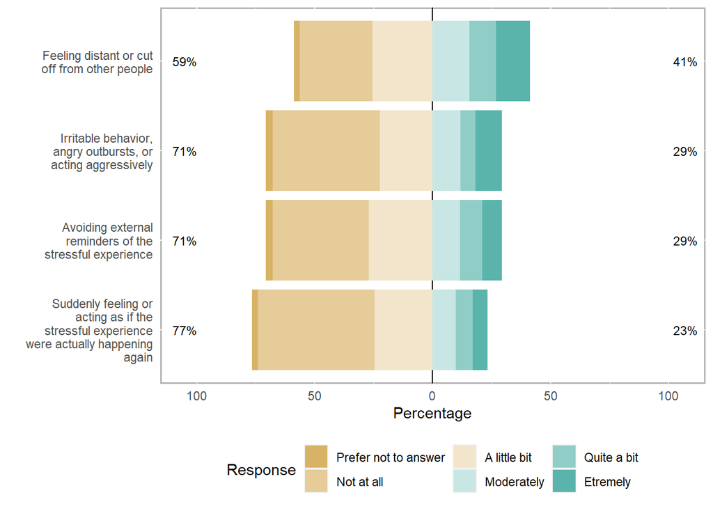

Vanguard Survey – PTSD Questions, by SNAP variable  
“Below is a list of problems that people sometimes have in response to a very stressful experience. Please read each problem carefully and then circle one of the numbers to the right to indicate how much you have been bothered by that problem in the past 30 days. In the past 30 days, how much were you bothered by:”

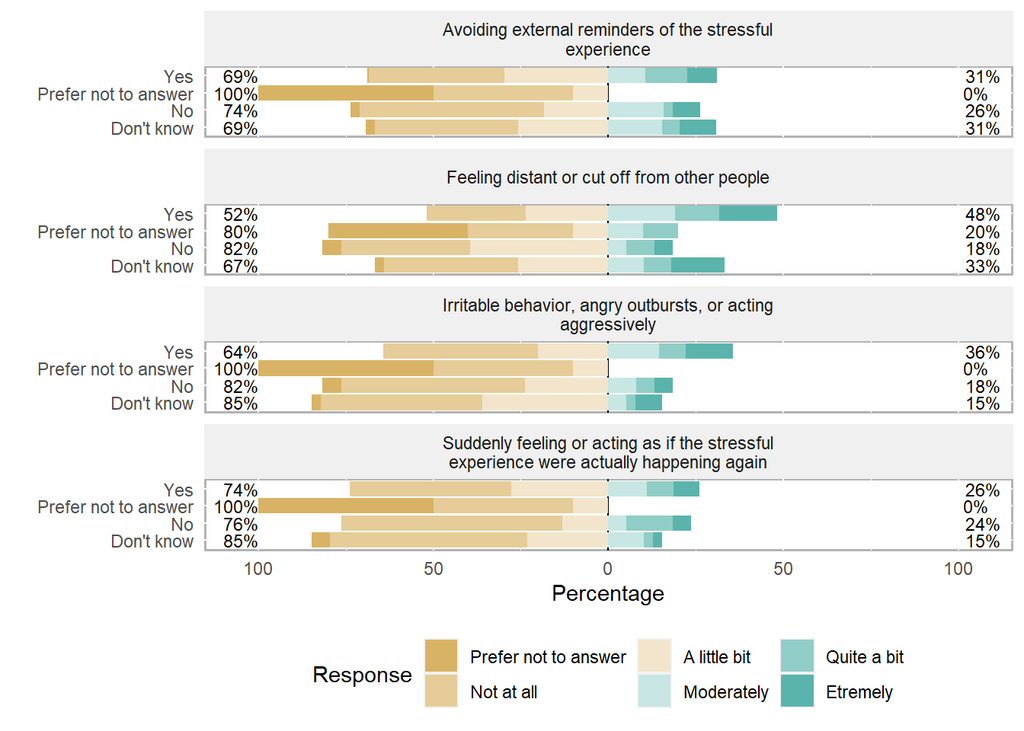

### PTSD/Trauma Tables

Cross Tab - Vanguard, SNAP and PTSD Flag

```
##
##
##    Cell Contents
## |-------------------------|
## |                       N |
## |           N / Row Total |
## |-------------------------|
##
##
## Total Observations in Table:  286
##
##
##                      | PTSD Flag, >=7 (max: 16)
##                 SNAP |         0 |         1 | Row Total |
## ---------------------|-----------|-----------|-----------|
##           Don't know |        28 |        11 |        39 |
##                      |      0.72 |      0.28 |      0.14 |
## ---------------------|-----------|-----------|-----------|
##                   No |        27 |        11 |        38 |
##                      |      0.71 |      0.29 |      0.13 |
## ---------------------|-----------|-----------|-----------|
## Prefer not to answer |         5 |         5 |        10 |
##                      |      0.50 |      0.50 |      0.03 |
## ---------------------|-----------|-----------|-----------|
##                  Yes |       133 |        66 |       199 |
##                      |      0.67 |      0.33 |      0.70 |
## ---------------------|-----------|-----------|-----------|
##         Column Total |       193 |        93 |       286 |
## ---------------------|-----------|-----------|-----------|
##
##
```

**“Suddenly feeling or acting as if the stressful experience were actually happening again”**

| snap | Prefer not to answer | Not at all | A little bit | Moderately | Quite a bit | Etremely | Total |
| --- | --- | --- | --- | --- | --- | --- | --- |
| Don’t know | 2 (2.6%) | 22 (28.2%) | 9 (11.5%) | 4 (5.1%) | 1 (1.3%) | 1 (1.3%) | 39 (50.0%) |
| No | 0 (0.0%) | 24 (31.6%) | 5 (6.6%) | 2 (2.6%) | 5 (6.6%) | 2 (2.6%) | 38 (50.0%) |
| Prefer not to answer | 5 (25.0%) | 4 (20.0%) | 1 (5.0%) | 0 (0.0%) | 0 (0.0%) | 0 (0.0%) | 10 (50.0%) |
| Yes | 0 (0.0%) | 92 (23.1%) | 55 (13.8%) | 22 (5.5%) | 15 (3.8%) | 15 (3.8%) | 199 (50.0%) |
| Total | 7 (1.2%) | 142 (24.8%) | 70 (12.2%) | 28 (4.9%) | 21 (3.7%) | 18 (3.1%) | 286 (50.0%) |

**“Avoiding external reminders of the stressful experience”**

| snap | Prefer not to answer | Not at all | A little bit | Moderately | Quite a bit | Etremely | Total |
| --- | --- | --- | --- | --- | --- | --- | --- |
| Don’t know | 1 (1.3%) | 16 (20.5%) | 10 (12.8%) | 6 (7.7%) | 2 (2.6%) | 4 (5.1%) | 39 (50.0%) |
| No | 1 (1.3%) | 20 (26.3%) | 7 (9.2%) | 6 (7.9%) | 1 (1.3%) | 3 (3.9%) | 38 (50.0%) |
| Prefer not to answer | 5 (25.0%) | 4 (20.0%) | 1 (5.0%) | 0 (0.0%) | 0 (0.0%) | 0 (0.0%) | 10 (50.0%) |
| Yes | 1 (0.3%) | 77 (19.3%) | 59 (14.8%) | 21 (5.3%) | 24 (6.0%) | 17 (4.3%) | 199 (50.0%) |
| Total | 8 (1.4%) | 117 (20.5%) | 77 (13.5%) | 33 (5.8%) | 27 (4.7%) | 24 (4.2%) | 286 (50.0%) |

**“Feeling distant or cut off from other people”**

| snap | Prefer not to answer | Not at all | A little bit | Moderately | Quite a bit | Etremely | Total |
| --- | --- | --- | --- | --- | --- | --- | --- |
| Don’t know | 1 (1.3%) | 15 (19.2%) | 10 (12.8%) | 4 (5.1%) | 3 (3.8%) | 6 (7.7%) | 39 (50.0%) |
| No | 2 (2.6%) | 14 (18.4%) | 15 (19.7%) | 2 (2.6%) | 3 (3.9%) | 2 (2.6%) | 38 (50.0%) |
| Prefer not to answer | 4 (20.0%) | 3 (15.0%) | 1 (5.0%) | 1 (5.0%) | 1 (5.0%) | 0 (0.0%) | 10 (50.0%) |
| Yes | 0 (0.0%) | 56 (14.1%) | 47 (11.8%) | 38 (9.5%) | 25 (6.3%) | 33 (8.3%) | 199 (50.0%) |
| Total | 7 (1.2%) | 88 (15.4%) | 73 (12.8%) | 45 (7.9%) | 32 (5.6%) | 41 (7.2%) | 286 (50.0%) |

**“Irritable behavior, angry outbursts, or acting aggressively”**

| snap | Prefer not to answer | Not at all | A little bit | Moderately | Quite a bit | Etremely | Total |
| --- | --- | --- | --- | --- | --- | --- | --- |
| Don’t know | 1 (1.3%) | 18 (23.1%) | 14 (17.9%) | 2 (2.6%) | 1 (1.3%) | 3 (3.8%) | 39 (50.0%) |
| No | 2 (2.6%) | 20 (26.3%) | 9 (11.8%) | 3 (3.9%) | 2 (2.6%) | 2 (2.6%) | 38 (50.0%) |
| Prefer not to answer | 5 (25.0%) | 4 (20.0%) | 1 (5.0%) | 0 (0.0%) | 0 (0.0%) | 0 (0.0%) | 10 (50.0%) |
| Yes | 0 (0.0%) | 88 (22.1%) | 40 (10.1%) | 29 (7.3%) | 15 (3.8%) | 27 (6.8%) | 199 (50.0%) |
| Total | 8 (1.4%) | 130 (22.7%) | 64 (11.2%) | 34 (5.9%) | 18 (3.1%) | 32 (5.6%) | 286 (50.0%) |

### Depression Graphs

Vanguard Survey – Depression Questions  
Below is a list of the ways you might have felt or behaved. Please tell me how often you have felt this way during the past 7 days.

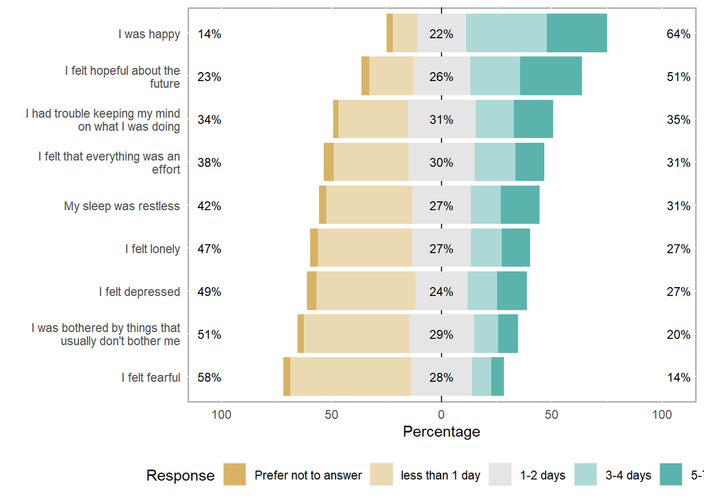

Vanguard Survey – Depression Questions, by SNAP variable  
Below is a list of the ways you might have felt or behaved. Please tell me how often you have felt this way during the past 7 days.

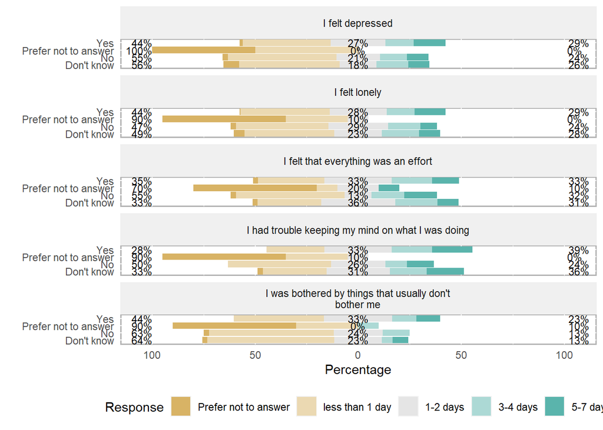

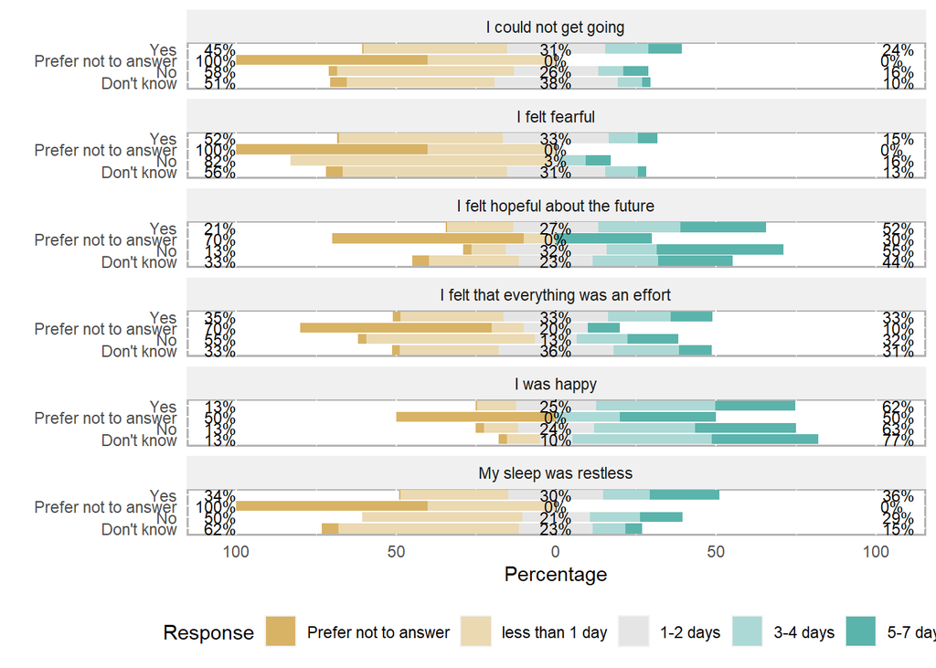

### Depression Tables

Cross Tab - Vanguard, SNAP and DEPRESSION Flag

```
##
##
##    Cell Contents
## |-------------------------|
## |                       N |
## |           N / Row Total |
## |-------------------------|
##
##
## Total Observations in Table:  286
##
##
##                      | DEPRESSION Flag, >=9 (max: 30)
##                 SNAP |         0 |         1 | Row Total |
## ---------------------|-----------|-----------|-----------|
##           Don't know |        14 |        25 |        39 |
##                      |      0.36 |      0.64 |      0.14 |
## ---------------------|-----------|-----------|-----------|
##                   No |        21 |        17 |        38 |
##                      |      0.55 |      0.45 |      0.13 |
## ---------------------|-----------|-----------|-----------|
## Prefer not to answer |         4 |         6 |        10 |
##                      |      0.40 |      0.60 |      0.03 |
## ---------------------|-----------|-----------|-----------|
##                  Yes |        81 |       118 |       199 |
##                      |      0.41 |      0.59 |      0.70 |
## ---------------------|-----------|-----------|-----------|
##         Column Total |       120 |       166 |       286 |
## ---------------------|-----------|-----------|-----------|
##
##
```

**I was bothered by things that usually don’t bother me**

| snap | Prefer not to answer | less than 1 day | 1-2 days | 3-4 days | 5-7 days | Total |
| --- | --- | --- | --- | --- | --- | --- |
| Don’t know | 1 (1.3%) | 24 (30.8%) | 9 (11.5%) | 2 (2.6%) | 3 (3.8%) | 39 (50.0%) |
| No | 1 (1.3%) | 23 (30.3%) | 9 (11.8%) | 5 (6.6%) | 0 (0.0%) | 38 (50.0%) |
| Prefer not to answer | 6 (30.0%) | 3 (15.0%) | 0 (0.0%) | 1 (5.0%) | 0 (0.0%) | 10 (50.0%) |
| Yes | 0 (0.0%) | 87 (21.9%) | 66 (16.6%) | 23 (5.8%) | 23 (5.8%) | 199 (50.0%) |
| Total | 8 (1.4%) | 137 (24.0%) | 84 (14.7%) | 31 (5.4%) | 26 (4.5%) | 286 (50.0%) |

**I had trouble keeping my mind on what I was doing**

| snap | Prefer not to answer | less than 1 day | 1-2 days | 3-4 days | 5-7 days | Total |
| --- | --- | --- | --- | --- | --- | --- |
| Don’t know | 1 (1.3%) | 12 (15.4%) | 12 (15.4%) | 7 (9.0%) | 7 (9.0%) | 39 (50.0%) |
| No | 0 (0.0%) | 19 (25.0%) | 10 (13.2%) | 4 (5.3%) | 5 (6.6%) | 38 (50.0%) |
| Prefer not to answer | 6 (30.0%) | 3 (15.0%) | 1 (5.0%) | 0 (0.0%) | 0 (0.0%) | 10 (50.0%) |
| Yes | 0 (0.0%) | 56 (14.1%) | 65 (16.3%) | 39 (9.8%) | 39 (9.8%) | 199 (50.0%) |
| Total | 7 (1.2%) | 90 (15.7%) | 88 (15.4%) | 50 (8.7%) | 51 (8.9%) | 286 (50.0%) |

**I felt lonely**

| snap | Prefer not to answer | less than 1 day | 1-2 days | 3-4 days | 5-7 days | Total |
| --- | --- | --- | --- | --- | --- | --- |
| Don’t know | 2 (2.6%) | 17 (21.8%) | 9 (11.5%) | 7 (9.0%) | 4 (5.1%) | 39 (50.0%) |
| No | 1 (1.3%) | 17 (22.4%) | 11 (14.5%) | 6 (7.9%) | 3 (3.9%) | 38 (50.0%) |
| Prefer not to answer | 6 (30.0%) | 3 (15.0%) | 1 (5.0%) | 0 (0.0%) | 0 (0.0%) | 10 (50.0%) |
| Yes | 1 (0.3%) | 86 (21.6%) | 55 (13.8%) | 27 (6.8%) | 30 (7.5%) | 199 (50.0%) |
| Total | 10 (1.7%) | 123 (21.5%) | 76 (13.3%) | 40 (7.0%) | 37 (6.5%) | 286 (50.0%) |

**I felt depressed**

| snap | Prefer not to answer | less than 1 day | 1-2 days | 3-4 days | 5-7 days | Total |
| --- | --- | --- | --- | --- | --- | --- |
| Don’t know | 3 (3.8%) | 19 (24.4%) | 7 (9.0%) | 6 (7.7%) | 4 (5.1%) | 39 (50.0%) |
| No | 1 (1.3%) | 20 (26.3%) | 8 (10.5%) | 5 (6.6%) | 4 (5.3%) | 38 (50.0%) |
| Prefer not to answer | 5 (25.0%) | 5 (25.0%) | 0 (0.0%) | 0 (0.0%) | 0 (0.0%) | 10 (50.0%) |
| Yes | 3 (0.8%) | 85 (21.4%) | 53 (13.3%) | 27 (6.8%) | 31 (7.8%) | 199 (50.0%) |
| Total | 12 (2.1%) | 129 (22.6%) | 68 (11.9%) | 38 (6.6%) | 39 (6.8%) | 286 (50.0%) |

**I felt that everything was an effort**

| snap | Prefer not to answer | less than 1 day | 1-2 days | 3-4 days | 5-7 days | Total |
| --- | --- | --- | --- | --- | --- | --- |
| Don’t know | 1 (1.3%) | 12 (15.4%) | 14 (17.9%) | 8 (10.3%) | 4 (5.1%) | 39 (50.0%) |
| No | 1 (1.3%) | 20 (26.3%) | 5 (6.6%) | 6 (7.9%) | 6 (7.9%) | 38 (50.0%) |
| Prefer not to answer | 6 (30.0%) | 1 (5.0%) | 2 (10.0%) | 0 (0.0%) | 1 (5.0%) | 10 (50.0%) |
| Yes | 5 (1.3%) | 64 (16.1%) | 65 (16.3%) | 39 (9.8%) | 26 (6.5%) | 199 (50.0%) |
| Total | 13 (2.3%) | 97 (17.0%) | 86 (15.0%) | 53 (9.3%) | 37 (6.5%) | 286 (50.0%) |

**I felt hopeful about the future**

| snap | Prefer not to answer | less than 1 day | 1-2 days | 3-4 days | 5-7 days | Total |
| --- | --- | --- | --- | --- | --- | --- |
| Don’t know | 2 (2.6%) | 11 (14.1%) | 9 (11.5%) | 8 (10.3%) | 9 (11.5%) | 39 (50.0%) |
| No | 1 (1.3%) | 4 (5.3%) | 12 (15.8%) | 6 (7.9%) | 15 (19.7%) | 38 (50.0%) |
| Prefer not to answer | 6 (30.0%) | 1 (5.0%) | 0 (0.0%) | 0 (0.0%) | 3 (15.0%) | 10 (50.0%) |
| Yes | 1 (0.3%) | 41 (10.3%) | 53 (13.3%) | 51 (12.8%) | 53 (13.3%) | 199 (50.0%) |
| Total | 10 (1.7%) | 57 (10.0%) | 74 (12.9%) | 65 (11.4%) | 80 (14.0%) | 286 (50.0%) |

**I felt fearful**

| snap | Prefer not to answer | less than 1 day | 1-2 days | 3-4 days | 5-7 days | Total |
| --- | --- | --- | --- | --- | --- | --- |
| Don’t know | 2 (2.6%) | 20 (25.6%) | 12 (15.4%) | 4 (5.1%) | 1 (1.3%) | 39 (50.0%) |
| No | 0 (0.0%) | 31 (40.8%) | 1 (1.3%) | 3 (3.9%) | 3 (3.9%) | 38 (50.0%) |
| Prefer not to answer | 6 (30.0%) | 4 (20.0%) | 0 (0.0%) | 0 (0.0%) | 0 (0.0%) | 10 (50.0%) |
| Yes | 1 (0.3%) | 102 (25.6%) | 66 (16.6%) | 18 (4.5%) | 12 (3.0%) | 199 (50.0%) |
| Total | 9 (1.6%) | 157 (27.4%) | 79 (13.8%) | 25 (4.4%) | 16 (2.8%) | 286 (50.0%) |

**My sleep was restless**

| snap | Prefer not to answer | less than 1 day | 1-2 days | 3-4 days | 5-7 days | Total |
| --- | --- | --- | --- | --- | --- | --- |
| Don’t know | 2 (2.6%) | 22 (28.2%) | 9 (11.5%) | 4 (5.1%) | 2 (2.6%) | 39 (50.0%) |
| No | 0 (0.0%) | 19 (25.0%) | 8 (10.5%) | 6 (7.9%) | 5 (6.6%) | 38 (50.0%) |
| Prefer not to answer | 6 (30.0%) | 4 (20.0%) | 0 (0.0%) | 0 (0.0%) | 0 (0.0%) | 10 (50.0%) |
| Yes | 1 (0.3%) | 67 (16.8%) | 59 (14.8%) | 29 (7.3%) | 43 (10.8%) | 199 (50.0%) |
| Total | 9 (1.6%) | 112 (19.6%) | 76 (13.3%) | 39 (6.8%) | 50 (8.7%) | 286 (50.0%) |

**I was happy**

| snap | Prefer not to answer | less than 1 day | 1-2 days | 3-4 days | 5-7 days | Total |
| --- | --- | --- | --- | --- | --- | --- |
| Don’t know | 1 (1.3%) | 4 (5.1%) | 4 (5.1%) | 17 (21.8%) | 13 (16.7%) | 39 (50.0%) |
| No | 1 (1.3%) | 4 (5.3%) | 9 (11.8%) | 12 (15.8%) | 12 (15.8%) | 38 (50.0%) |
| Prefer not to answer | 5 (25.0%) | 0 (0.0%) | 0 (0.0%) | 2 (10.0%) | 3 (15.0%) | 10 (50.0%) |
| Yes | 1 (0.3%) | 24 (6.0%) | 50 (12.6%) | 74 (18.6%) | 50 (12.6%) | 199 (50.0%) |
| Total | 8 (1.4%) | 32 (5.6%) | 63 (11.0%) | 105 (18.4%) | 78 (13.6%) | 286 (50.0%) |

**I could not get going**

| snap | Prefer not to answer | less than 1 day | 1-2 days | 3-4 days | 5-7 days | Total |
| --- | --- | --- | --- | --- | --- | --- |
| Don’t know | 2 (2.6%) | 18 (23.1%) | 15 (19.2%) | 3 (3.8%) | 1 (1.3%) | 39 (50.0%) |
| No | 1 (1.3%) | 21 (27.6%) | 10 (13.2%) | 3 (3.9%) | 3 (3.9%) | 38 (50.0%) |
| Prefer not to answer | 6 (30.0%) | 4 (20.0%) | 0 (0.0%) | 0 (0.0%) | 0 (0.0%) | 10 (50.0%) |
| Yes | 1 (0.3%) | 89 (22.4%) | 61 (15.3%) | 27 (6.8%) | 21 (5.3%) | 199 (50.0%) |
| Total | 10 (1.7%) | 132 (23.1%) | 86 (15.0%) | 33 (5.8%) | 25 (4.4%) | 286 (50.0%) |

## 2. HEYBMORE

The influence of health on employment among young people in Baltimore

### Food Security Graphs

G2C Food Security Questions  
“The next set of questions will ask you about food in your household.  
**How often…”**

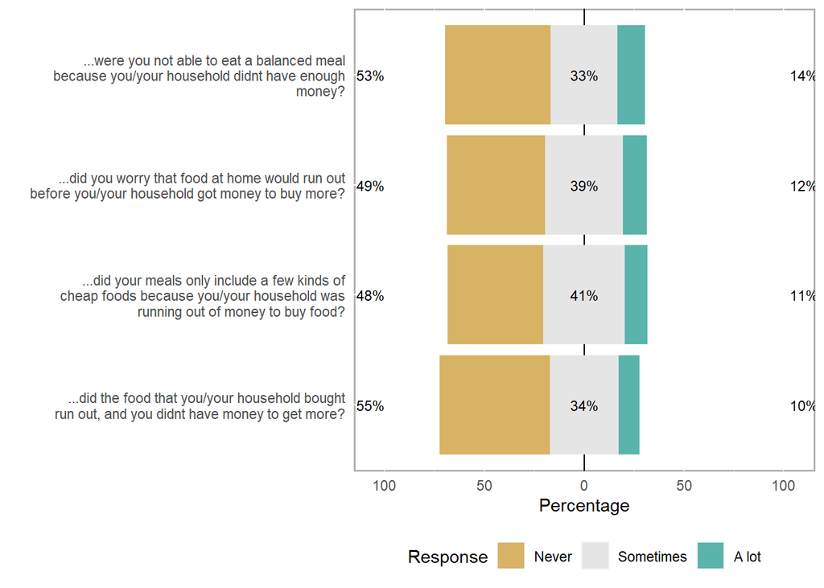

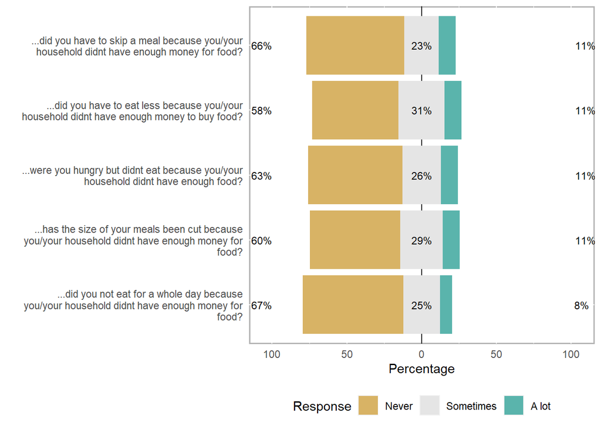

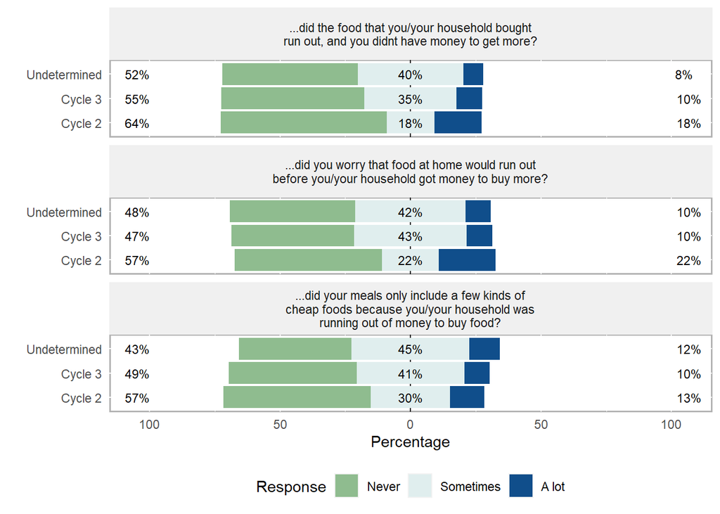

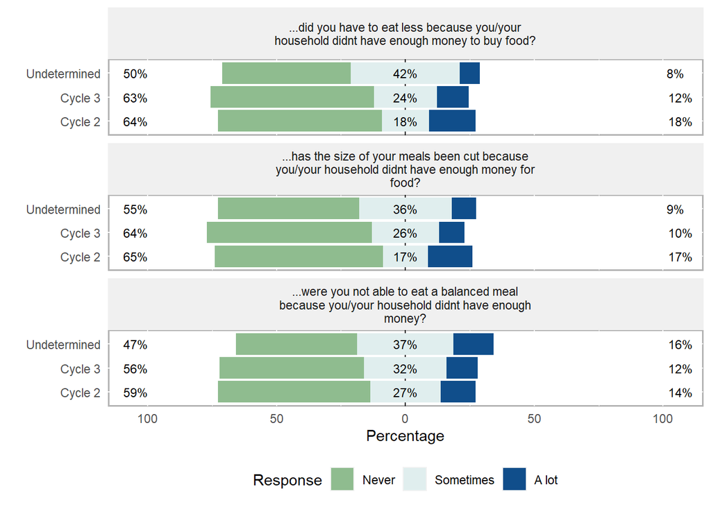

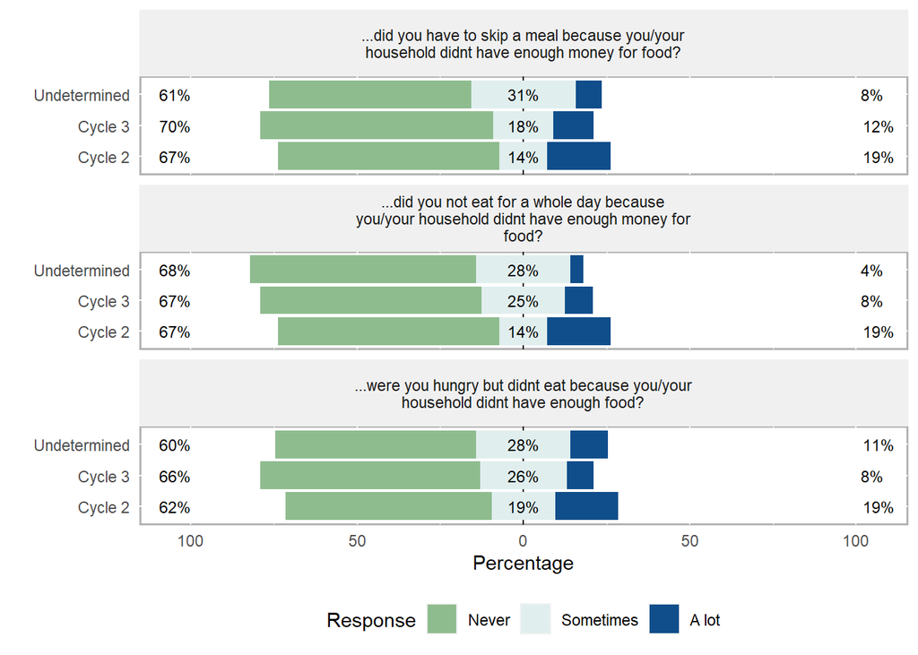

### Food Security Tables

Cross Tab - HEYBMORE, Cycle and Food Flag Moderate Food Insecurity:2-5 Severe Food Insecurity: >6

```
##
##
##    Cell Contents
## |-------------------------|
## |                       N |
## |           N / Row Total |
## |-------------------------|
##
##
## Total Observations in Table:  131
##
##
##              | Food Flag, >=2 (max: 18)
##        CYCLE |  Moderate |      None | Row Total |
## -------------|-----------|-----------|-----------|
##      Cycle 2 |        13 |        10 |        23 |
##              |      0.57 |      0.43 |      0.18 |
## -------------|-----------|-----------|-----------|
##      Cycle 3 |        32 |        22 |        54 |
##              |      0.59 |      0.41 |      0.41 |
## -------------|-----------|-----------|-----------|
## Undetermined |        33 |        21 |        54 |
##              |      0.61 |      0.39 |      0.41 |
## -------------|-----------|-----------|-----------|
## Column Total |        78 |        53 |       131 |
## -------------|-----------|-----------|-----------|
##
##
```

Cross Tab - HEYBMORE, G2C Participant and Food Flag 1 = Yes 2 = No 999 = “Don’t know”

```
##
##
##    Cell Contents
## |-------------------------|
## |                       N |
## |           N / Row Total |
## |-------------------------|
##
##
## Total Observations in Table:  130
##
##
##                | Food Flag, >=2 (max: 18
## G2C Participan |         0 |         1 | Row Total |
## ---------------|-----------|-----------|-----------|
##              1 |         4 |         7 |        11 |
##                |      0.36 |      0.64 |      0.08 |
## ---------------|-----------|-----------|-----------|
##              2 |        21 |        37 |        58 |
##                |      0.36 |      0.64 |      0.45 |
## ---------------|-----------|-----------|-----------|
##            999 |        28 |        33 |        61 |
##                |      0.46 |      0.54 |      0.47 |
## ---------------|-----------|-----------|-----------|
##   Column Total |        53 |        77 |       130 |
## ---------------|-----------|-----------|-----------|
##
##
```

“The next set of questions will ask you about food in your household.  
How often…”

**“…did you worry that food at home would run out before you/your household got money to buy more?”**

| cycle1 | Prefer not to answer | Never | Sometimes | A lot | Total |
| --- | --- | --- | --- | --- | --- |
| Cycle 2 | 0 (0.0%) | 13 (28.3%) | 5 (10.9%) | 5 (10.9%) | 23 (50.0%) |
| Cycle 3 | 3 (2.8%) | 24 (22.2%) | 22 (20.4%) | 5 (4.6%) | 54 (50.0%) |
| Undetermined | 2 (1.9%) | 25 (23.1%) | 22 (20.4%) | 5 (4.6%) | 54 (50.0%) |
| Total | 5 (1.9%) | 62 (23.7%) | 49 (18.7%) | 15 (5.7%) | 131 (50.0%) |

**“…did the food that you/your household bought run out, and you didnt have money to get more?”**

| cycle1 | Prefer not to answer | Never | Sometimes | A lot | Total |
| --- | --- | --- | --- | --- | --- |
| Cycle 2 | 1 (2.2%) | 14 (30.4%) | 4 (8.7%) | 4 (8.7%) | 23 (50.0%) |
| Cycle 3 | 3 (2.8%) | 28 (25.9%) | 18 (16.7%) | 5 (4.6%) | 54 (50.0%) |
| Undetermined | 2 (1.9%) | 27 (25.0%) | 21 (19.4%) | 4 (3.7%) | 54 (50.0%) |
| Total | 6 (2.3%) | 69 (26.3%) | 43 (16.4%) | 13 (5.0%) | 131 (50.0%) |

**“…did your meals only include a few kinds of cheap foods because you/your household was running out of money to buy food?”**

| cycle1 | Prefer not to answer | Never | Sometimes | A lot | Total |
| --- | --- | --- | --- | --- | --- |
| Cycle 2 | 0 (0.0%) | 13 (28.3%) | 7 (15.2%) | 3 (6.5%) | 23 (50.0%) |
| Cycle 3 | 3 (2.8%) | 25 (23.1%) | 21 (19.4%) | 5 (4.6%) | 54 (50.0%) |
| Undetermined | 3 (2.8%) | 22 (20.4%) | 23 (21.3%) | 6 (5.6%) | 54 (50.0%) |
| Total | 6 (2.3%) | 60 (22.9%) | 51 (19.5%) | 14 (5.3%) | 131 (50.0%) |

**“…were you not able to eat a balanced meal because you/your household didnt have enough money?”**

| cycle1 | Prefer not to answer | Never | Sometimes | A lot | Total |
| --- | --- | --- | --- | --- | --- |
| Cycle 2 | 1 (2.2%) | 13 (28.3%) | 6 (13.0%) | 3 (6.5%) | 23 (50.0%) |
| Cycle 3 | 4 (3.7%) | 28 (25.9%) | 16 (14.8%) | 6 (5.6%) | 54 (50.0%) |
| Undetermined | 3 (2.8%) | 24 (22.2%) | 19 (17.6%) | 8 (7.4%) | 54 (50.0%) |
| Total | 8 (3.1%) | 65 (24.8%) | 41 (15.6%) | 17 (6.5%) | 131 (50.0%) |

**“…did you have to eat less because you/your household didnt have enough money to buy food?”**

| cycle1 | Prefer not to answer | Never | Sometimes | A lot | Total |
| --- | --- | --- | --- | --- | --- |
| Cycle 2 | 1 (2.2%) | 14 (30.4%) | 4 (8.7%) | 4 (8.7%) | 23 (50.0%) |
| Cycle 3 | 5 (4.6%) | 31 (28.7%) | 12 (11.1%) | 6 (5.6%) | 54 (50.0%) |
| Undetermined | 2 (1.9%) | 26 (24.1%) | 22 (20.4%) | 4 (3.7%) | 54 (50.0%) |
| Total | 8 (3.1%) | 71 (27.1%) | 38 (14.5%) | 14 (5.3%) | 131 (50.0%) |

**“…has the size of your meals been cut because you/your household didnt have enough money for food?”**

| cycle1 | Prefer not to answer | Never | Sometimes | A lot | Total |
| --- | --- | --- | --- | --- | --- |
| Cycle 2 | 0 (0.0%) | 15 (32.6%) | 4 (8.7%) | 4 (8.7%) | 23 (50.0%) |
| Cycle 3 | 4 (3.7%) | 32 (29.6%) | 13 (12.0%) | 5 (4.6%) | 54 (50.0%) |
| Undetermined | 1 (0.9%) | 29 (26.9%) | 19 (17.6%) | 5 (4.6%) | 54 (50.0%) |
| Total | 5 (1.9%) | 76 (29.0%) | 36 (13.7%) | 14 (5.3%) | 131 (50.0%) |

**“…did you have to skip a meal because you/your household didnt have enough money for food?”**

| cycle1 | Prefer not to answer | Never | Sometimes | A lot | Total |
| --- | --- | --- | --- | --- | --- |
| Cycle 2 | 2 (4.3%) | 14 (30.4%) | 3 (6.5%) | 4 (8.7%) | 23 (50.0%) |
| Cycle 3 | 4 (3.7%) | 35 (32.4%) | 9 (8.3%) | 6 (5.6%) | 54 (50.0%) |
| Undetermined | 3 (2.8%) | 31 (28.7%) | 16 (14.8%) | 4 (3.7%) | 54 (50.0%) |
| Total | 9 (3.4%) | 80 (30.5%) | 28 (10.7%) | 14 (5.3%) | 131 (50.0%) |

**“…were you hungry but didnt eat because you/your household didnt have enough food?”**

| cycle1 | Prefer not to answer | Never | Sometimes | A lot | Total |
| --- | --- | --- | --- | --- | --- |
| Cycle 2 | 2 (4.3%) | 13 (28.3%) | 4 (8.7%) | 4 (8.7%) | 23 (50.0%) |
| Cycle 3 | 4 (3.7%) | 33 (30.6%) | 13 (12.0%) | 4 (3.7%) | 54 (50.0%) |
| Undetermined | 1 (0.9%) | 32 (29.6%) | 15 (13.9%) | 6 (5.6%) | 54 (50.0%) |
| Total | 7 (2.7%) | 78 (29.8%) | 32 (12.2%) | 14 (5.3%) | 131 (50.0%) |

**“…did you not eat for a whole day because you/your household didnt have enough money for food?”**

| cycle1 | Prefer not to answer | Never | Sometimes | A lot | Total |
| --- | --- | --- | --- | --- | --- |
| Cycle 2 | 2 (4.3%) | 14 (30.4%) | 3 (6.5%) | 4 (8.7%) | 23 (50.0%) |
| Cycle 3 | 6 (5.6%) | 32 (29.6%) | 12 (11.1%) | 4 (3.7%) | 54 (50.0%) |
| Undetermined | 1 (0.9%) | 36 (33.3%) | 15 (13.9%) | 2 (1.9%) | 54 (50.0%) |
| Total | 9 (3.4%) | 82 (31.3%) | 30 (11.5%) | 10 (3.8%) | 131 (50.0%) |

### Anxiety Graphs

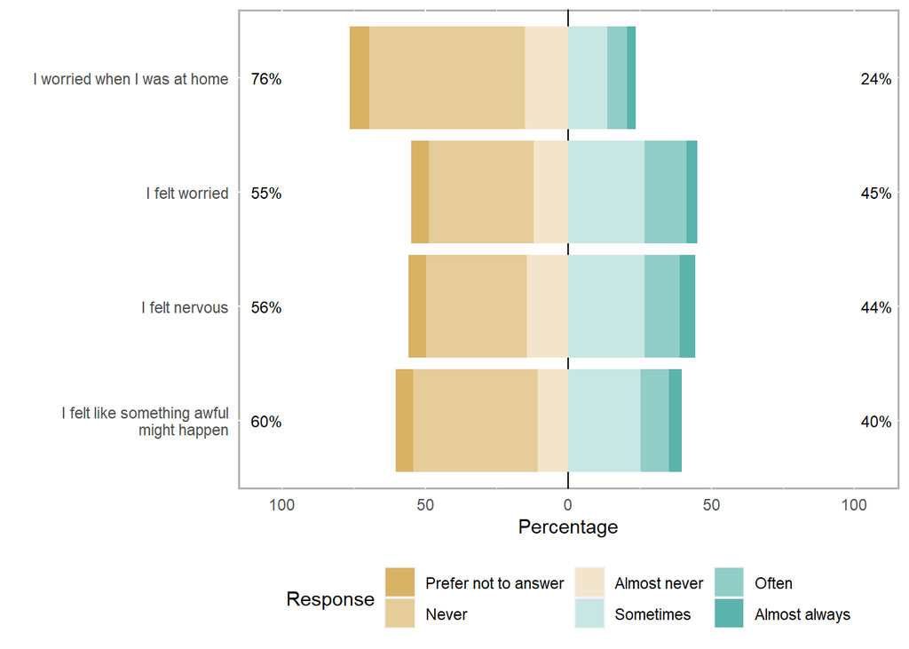

G2C Survey – Anxiety Questions, by SNAP variable  
“Please answer the following questions based on how you felt in the past 7 days.”

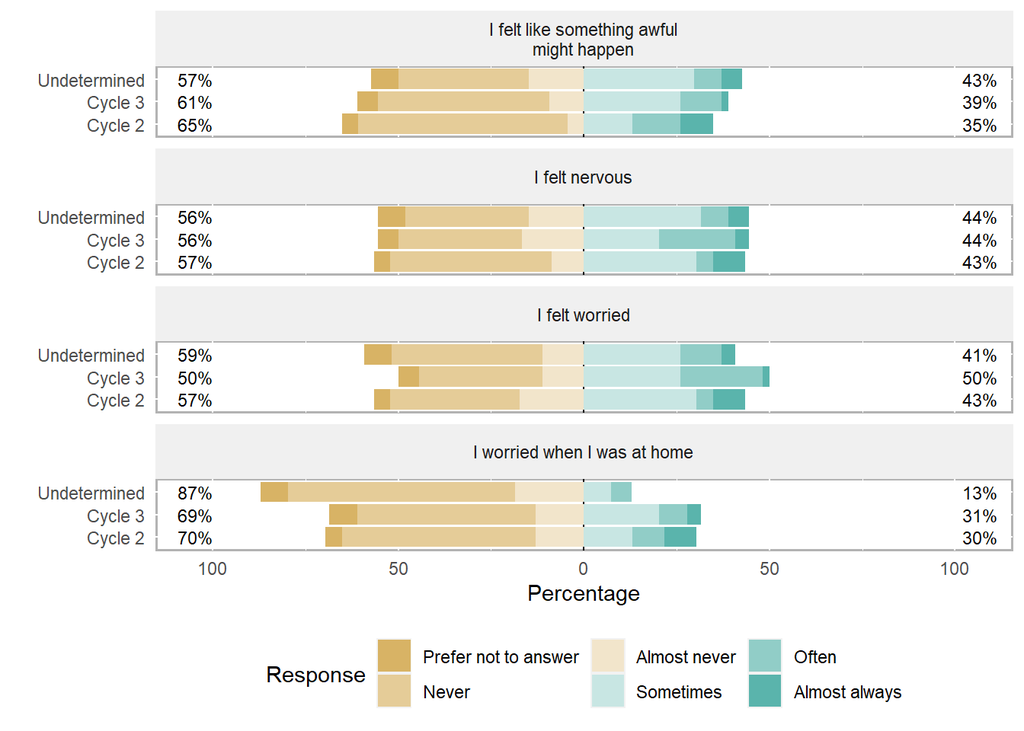

### Anxiety Tables

Cross Tab - HEYBMORE, CYCLE and ANXIETY Flag

```
##
##
##    Cell Contents
## |-------------------------|
## |                       N |
## |           N / Row Total |
## |-------------------------|
##
##
## Total Observations in Table:  131
##
##
##              | ANXIETY Flag, >=8 (max: 16)
##        CYCLE |         0 |         1 | Row Total |
## -------------|-----------|-----------|-----------|
##      Cycle 2 |        15 |         8 |        23 |
##              |      0.65 |      0.35 |      0.18 |
## -------------|-----------|-----------|-----------|
##      Cycle 3 |        33 |        21 |        54 |
##              |      0.61 |      0.39 |      0.41 |
## -------------|-----------|-----------|-----------|
## Undetermined |        39 |        15 |        54 |
##              |      0.72 |      0.28 |      0.41 |
## -------------|-----------|-----------|-----------|
## Column Total |        87 |        44 |       131 |
## -------------|-----------|-----------|-----------|
##
##
```

Cross Tab - HEYBMORE, G2C Participant and ANXIETY Flag 1 = Yes 2 = No 999 = “Don’t know”

```
##
##
##    Cell Contents
## |-------------------------|
## |                       N |
## |           N / Row Total |
## |-------------------------|
##
##
## Total Observations in Table:  130
##
##
##                 | ANXIETY Flag, >=8 (max: 16)
## G2C Participant |         0 |         1 | Row Total |
## ----------------|-----------|-----------|-----------|
##               1 |         7 |         4 |        11 |
##                 |      0.64 |      0.36 |      0.08 |
## ----------------|-----------|-----------|-----------|
##               2 |        42 |        16 |        58 |
##                 |      0.72 |      0.28 |      0.45 |
## ----------------|-----------|-----------|-----------|
##             999 |        38 |        23 |        61 |
##                 |      0.62 |      0.38 |      0.47 |
## ----------------|-----------|-----------|-----------|
##    Column Total |        87 |        43 |       130 |
## ----------------|-----------|-----------|-----------|
##
##
```

**“I felt like something awful might happen”**

| cycle1 | Prefer not to answer | Never | Almost never | Sometimes | Often | Almost always | Total |
| --- | --- | --- | --- | --- | --- | --- | --- |
| Cycle 2 | 1 (2.2%) | 13 (28.3%) | 1 (2.2%) | 3 (6.5%) | 3 (6.5%) | 2 (4.3%) | 23 (50.0%) |
| Cycle 3 | 3 (2.8%) | 25 (23.1%) | 5 (4.6%) | 14 (13.0%) | 6 (5.6%) | 1 (0.9%) | 54 (50.0%) |
| Undetermined | 4 (3.7%) | 19 (17.6%) | 8 (7.4%) | 16 (14.8%) | 4 (3.7%) | 3 (2.8%) | 54 (50.0%) |
| Total | 8 (3.1%) | 57 (21.8%) | 14 (5.3%) | 33 (12.6%) | 13 (5.0%) | 6 (2.3%) | 131 (50.0%) |

**“I felt nervous”**

| cycle1 | Prefer not to answer | Never | Almost never | Sometimes | Often | Almost always | Total |
| --- | --- | --- | --- | --- | --- | --- | --- |
| Cycle 2 | 1 (2.2%) | 10 (21.7%) | 2 (4.3%) | 7 (15.2%) | 1 (2.2%) | 2 (4.3%) | 23 (50.0%) |
| Cycle 3 | 3 (2.8%) | 18 (16.7%) | 9 (8.3%) | 11 (10.2%) | 11 (10.2%) | 2 (1.9%) | 54 (50.0%) |
| Undetermined | 4 (3.7%) | 18 (16.7%) | 8 (7.4%) | 17 (15.7%) | 4 (3.7%) | 3 (2.8%) | 54 (50.0%) |
| Total | 8 (3.1%) | 46 (17.6%) | 19 (7.3%) | 35 (13.4%) | 16 (6.1%) | 7 (2.7%) | 131 (50.0%) |

**“I felt worried”**

| cycle1 | Prefer not to answer | Never | Almost never | Sometimes | Often | Almost always | Total |
| --- | --- | --- | --- | --- | --- | --- | --- |
| Cycle 2 | 1 (2.2%) | 8 (17.4%) | 4 (8.7%) | 7 (15.2%) | 1 (2.2%) | 2 (4.3%) | 23 (50.0%) |
| Cycle 3 | 3 (2.8%) | 18 (16.7%) | 6 (5.6%) | 14 (13.0%) | 12 (11.1%) | 1 (0.9%) | 54 (50.0%) |
| Undetermined | 4 (3.7%) | 22 (20.4%) | 6 (5.6%) | 14 (13.0%) | 6 (5.6%) | 2 (1.9%) | 54 (50.0%) |
| Total | 8 (3.1%) | 48 (18.3%) | 16 (6.1%) | 35 (13.4%) | 19 (7.3%) | 5 (1.9%) | 131 (50.0%) |

**“I worried when I was at home”**

| cycle1 | Prefer not to answer | Never | Almost never | Sometimes | Often | Almost always | Total |
| --- | --- | --- | --- | --- | --- | --- | --- |
| Cycle 2 | 1 (2.2%) | 12 (26.1%) | 3 (6.5%) | 3 (6.5%) | 2 (4.3%) | 2 (4.3%) | 23 (50.0%) |
| Cycle 3 | 4 (3.7%) | 26 (24.1%) | 7 (6.5%) | 11 (10.2%) | 4 (3.7%) | 2 (1.9%) | 54 (50.0%) |
| Undetermined | 4 (3.7%) | 33 (30.6%) | 10 (9.3%) | 4 (3.7%) | 3 (2.8%) | 0 (0.0%) | 54 (50.0%) |
| Total | 9 (3.4%) | 71 (27.1%) | 20 (7.6%) | 18 (6.9%) | 9 (3.4%) | 4 (1.5%) | 131 (50.0%) |

### PTSD/Trauma graphs

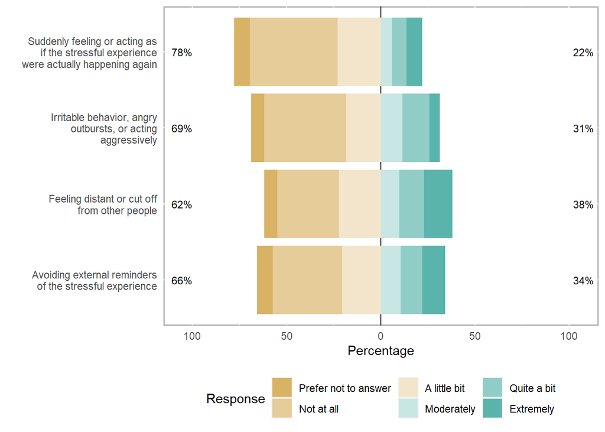

G2C Survey – ptsd Questions, by SNAP variable  
“Below is a list of problems that people sometimes have in response to a very stressful experience. Please read each problem carefully and then circle one of the numbers to the right to indicate how much you have been bothered by that problem in the past 30 days. In the past 30 days, how much were you bothered by:”

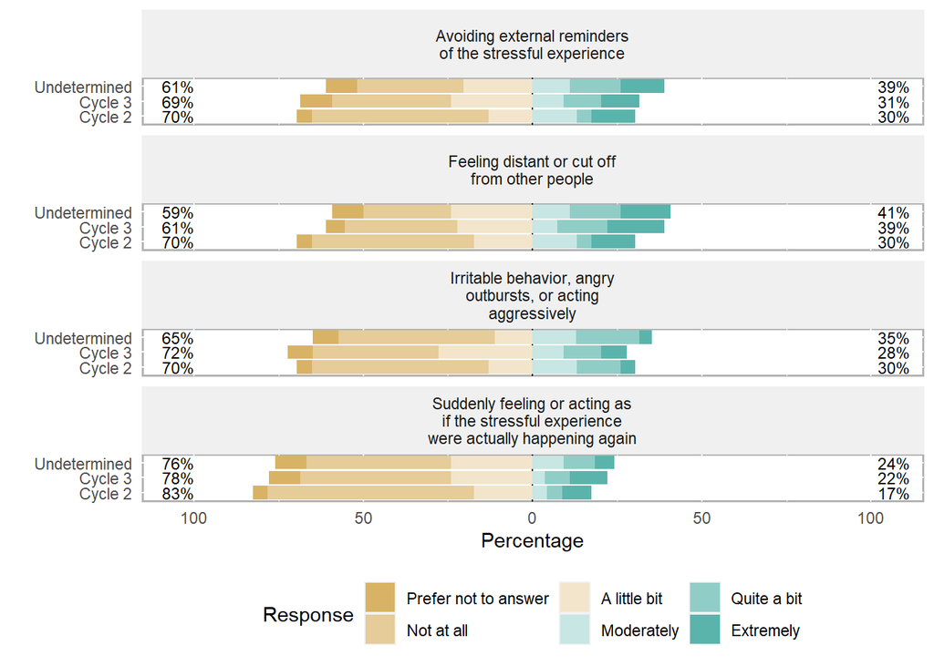

### PTSD/Trauma Tables

Cross Tab - HEYBMORE, CYCLE and PTSD Flag

```
##
##
##    Cell Contents
## |-------------------------|
## |                       N |
## |           N / Row Total |
## |-------------------------|
##
##
## Total Observations in Table:  131
##
##
##              | PTSD Flag, >=7 (max: 16)
##        CYCLE |         0 |         1 | Row Total |
## -------------|-----------|-----------|-----------|
##      Cycle 2 |        15 |         8 |        23 |
##              |      0.65 |      0.35 |      0.18 |
## -------------|-----------|-----------|-----------|
##      Cycle 3 |        32 |        22 |        54 |
##              |      0.59 |      0.41 |      0.41 |
## -------------|-----------|-----------|-----------|
## Undetermined |        29 |        25 |        54 |
##              |      0.54 |      0.46 |      0.41 |
## -------------|-----------|-----------|-----------|
## Column Total |        76 |        55 |       131 |
## -------------|-----------|-----------|-----------|
##
##
```

Cross Tab - HEYBMORE, G2C Participant and PTSD Flag 1 = Yes 2 = No 999 = “Don’t know”

```
##
##
##    Cell Contents
## |-------------------------|
## |                       N |
## |           N / Row Total |
## |-------------------------|
##
##
## Total Observations in Table:  130
##
##
##                 | PTSD Flag, >=7 (max: 16)
## G2C Participant |         0 |         1 | Row Total |
## ----------------|-----------|-----------|-----------|
##               1 |         9 |         2 |        11 |
##                 |      0.82 |      0.18 |      0.08 |
## ----------------|-----------|-----------|-----------|
##               2 |        31 |        27 |        58 |
##                 |      0.53 |      0.47 |      0.45 |
## ----------------|-----------|-----------|-----------|
##             999 |        35 |        26 |        61 |
##                 |      0.57 |      0.43 |      0.47 |
## ----------------|-----------|-----------|-----------|
##    Column Total |        75 |        55 |       130 |
## ----------------|-----------|-----------|-----------|
##
##
```

**“Suddenly feeling or acting as if the stressful experience were actually happening again”**

| cycle1 | Prefer not to answer | Not at all | A little bit | Moderately | Quite a bit | Extremely | Total |
| --- | --- | --- | --- | --- | --- | --- | --- |
| Cycle 2 | 1 (2.2%) | 14 (30.4%) | 4 (8.7%) | 1 (2.2%) | 1 (2.2%) | 2 (4.3%) | 23 (50.0%) |
| Cycle 3 | 5 (4.6%) | 24 (22.2%) | 13 (12.0%) | 2 (1.9%) | 4 (3.7%) | 6 (5.6%) | 54 (50.0%) |
| Undetermined | 5 (4.6%) | 23 (21.3%) | 13 (12.0%) | 5 (4.6%) | 5 (4.6%) | 3 (2.8%) | 54 (50.0%) |
| Total | 11 (4.2%) | 61 (23.3%) | 30 (11.5%) | 8 (3.1%) | 10 (3.8%) | 11 (4.2%) | 131 (50.0%) |

**“Avoiding external reminders of the stressful experience”**

| cycle1 | Prefer not to answer | Not at all | A little bit | Moderately | Quite a bit | Extremely | Total |
| --- | --- | --- | --- | --- | --- | --- | --- |
| Cycle 2 | 1 (2.2%) | 12 (26.1%) | 3 (6.5%) | 3 (6.5%) | 1 (2.2%) | 3 (6.5%) | 23 (50.0%) |
| Cycle 3 | 5 (4.6%) | 19 (17.6%) | 13 (12.0%) | 5 (4.6%) | 6 (5.6%) | 6 (5.6%) | 54 (50.0%) |
| Undetermined | 5 (4.6%) | 17 (15.7%) | 11 (10.2%) | 6 (5.6%) | 8 (7.4%) | 7 (6.5%) | 54 (50.0%) |
| Total | 11 (4.2%) | 48 (18.3%) | 27 (10.3%) | 14 (5.3%) | 15 (5.7%) | 16 (6.1%) | 131 (50.0%) |

**“Feeling distant or cut off from other people”**

| cycle1 | Prefer not to answer | Not at all | A little bit | Moderately | Quite a bit | Extremely | Total |
| --- | --- | --- | --- | --- | --- | --- | --- |
| Cycle 2 | 1 (2.2%) | 11 (23.9%) | 4 (8.7%) | 3 (6.5%) | 1 (2.2%) | 3 (6.5%) | 23 (50.0%) |
| Cycle 3 | 3 (2.8%) | 18 (16.7%) | 12 (11.1%) | 4 (3.7%) | 8 (7.4%) | 9 (8.3%) | 54 (50.0%) |
| Undetermined | 5 (4.6%) | 14 (13.0%) | 13 (12.0%) | 6 (5.6%) | 8 (7.4%) | 8 (7.4%) | 54 (50.0%) |
| Total | 9 (3.4%) | 43 (16.4%) | 29 (11.1%) | 13 (5.0%) | 17 (6.5%) | 20 (7.6%) | 131 (50.0%) |

**“Irritable behavior, angry outbursts, or acting aggressively”**

| cycle1 | Prefer not to answer | Not at all | A little bit | Moderately | Quite a bit | Extremely | Total |
| --- | --- | --- | --- | --- | --- | --- | --- |
| Cycle 2 | 1 (2.2%) | 12 (26.1%) | 3 (6.5%) | 3 (6.5%) | 3 (6.5%) | 1 (2.2%) | 23 (50.0%) |
| Cycle 3 | 4 (3.7%) | 20 (18.5%) | 15 (13.9%) | 5 (4.6%) | 6 (5.6%) | 4 (3.7%) | 54 (50.0%) |
| Undetermined | 4 (3.7%) | 25 (23.1%) | 6 (5.6%) | 7 (6.5%) | 10 (9.3%) | 2 (1.9%) | 54 (50.0%) |
| Total | 9 (3.4%) | 57 (21.8%) | 24 (9.2%) | 15 (5.7%) | 19 (7.3%) | 7 (2.7%) | 131 (50.0%) |

### Depression Graphs

**Below is a list of the ways you might have felt or behaved. Please tell me how often you have felt this way during the past 7 days.**

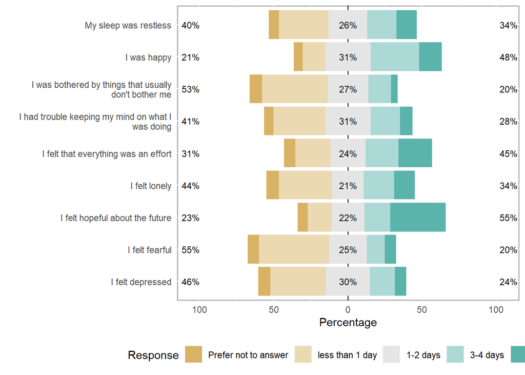

G2C Survey – Depression Questions, by SNAP variable  
Below is a list of the ways you might have felt or behaved. Please tell me how often you have felt this way during the past 7 days.

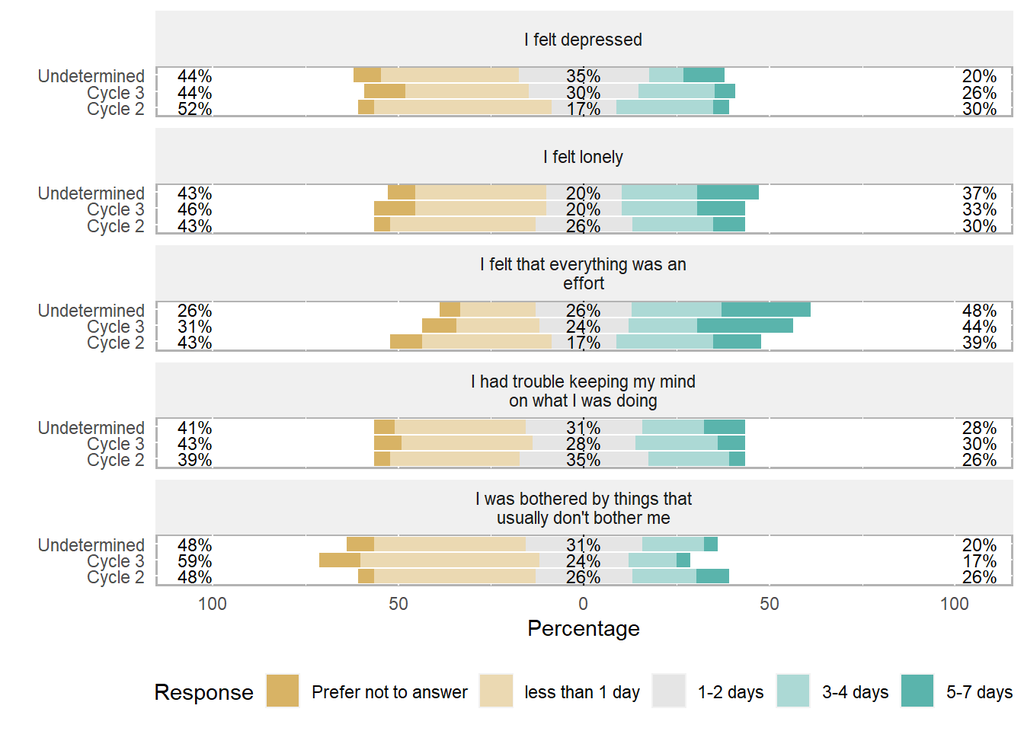

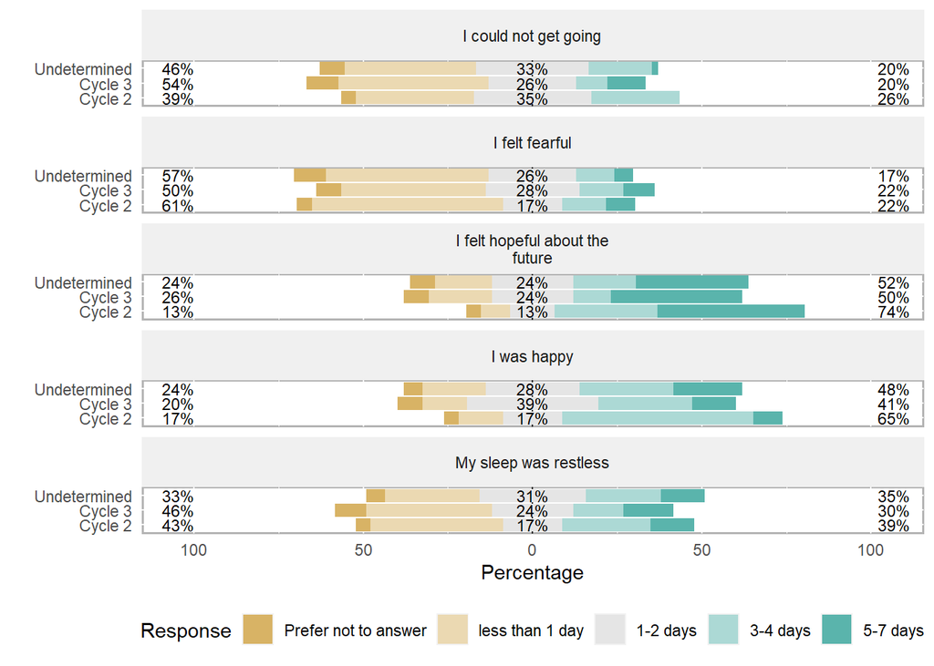

### Depression Tables

Cross Tab - HEYBMORE, CYCLE and DEPRESSION Flag

```
##
##
##    Cell Contents
## |-------------------------|
## |                       N |
## |           N / Row Total |
## |-------------------------|
##
##
## Total Observations in Table:  131
##
##
##              | DEPRESSION Flag, >=9 (max: 30)
##        CYCLE |         0 |         1 | Row Total |
## -------------|-----------|-----------|-----------|
##      Cycle 2 |        13 |        10 |        23 |
##              |      0.57 |      0.43 |      0.18 |
## -------------|-----------|-----------|-----------|
##      Cycle 3 |        18 |        36 |        54 |
##              |      0.33 |      0.67 |      0.41 |
## -------------|-----------|-----------|-----------|
## Undetermined |        16 |        38 |        54 |
##              |      0.30 |      0.70 |      0.41 |
## -------------|-----------|-----------|-----------|
## Column Total |        47 |        84 |       131 |
## -------------|-----------|-----------|-----------|
##
##
```

Cross Tab - HEYBMORE, G2C Participant and DEPRESSION Flag 1 = Yes 2 = No 999 = “Don’t know”

```
##
##
##    Cell Contents
## |-------------------------|
## |                       N |
## |           N / Row Total |
## |-------------------------|
##
##
## Total Observations in Table:  130
##
##
##                 | DEPRESSION Flag, >=9 (max: 30)
## G2C Participant |         0 |         1 | Row Total |
## ----------------|-----------|-----------|-----------|
##               1 |         6 |         5 |        11 |
##                 |      0.55 |      0.45 |      0.08 |
## ----------------|-----------|-----------|-----------|
##               2 |        15 |        43 |        58 |
##                 |      0.26 |      0.74 |      0.45 |
## ----------------|-----------|-----------|-----------|
##             999 |        25 |        36 |        61 |
##                 |      0.41 |      0.59 |      0.47 |
## ----------------|-----------|-----------|-----------|
##    Column Total |        46 |        84 |       130 |
## ----------------|-----------|-----------|-----------|
##
##
```

**I was bothered by things that usually don’t bother me**

| cycle1 | Prefer not to answer | less than 1 day | 1-2 days | 3-4 days | 5-7 days | Total |
| --- | --- | --- | --- | --- | --- | --- |
| Cycle 2 | 1 (2.2%) | 10 (21.7%) | 6 (13.0%) | 4 (8.7%) | 2 (4.3%) | 23 (50.0%) |
| Cycle 3 | 6 (5.6%) | 26 (24.1%) | 13 (12.0%) | 7 (6.5%) | 2 (1.9%) | 54 (50.0%) |
| Undetermined | 4 (3.7%) | 22 (20.4%) | 17 (15.7%) | 9 (8.3%) | 2 (1.9%) | 54 (50.0%) |
| Total | 11 (4.2%) | 58 (22.1%) | 36 (13.7%) | 20 (7.6%) | 6 (2.3%) | 131 (50.0%) |

**I had trouble keeping my mind on what I was doing**

[output not shown]

**I felt lonely**

[output not shown]

**I felt depressed**

[output not shown]

**I felt that everything was an effort**

[output not shown]

**I felt hopeful about the future**

[output not shown]

**I felt fearful**

[output not shown]

**My sleep was restless**

[output not shown]

**I was happy**

[output not shown]

**I could not get going**

[output not shown]

## 3. Comparison of Vanguard and HEYBMORE

### Food Insecurity

“The next set of questions will ask you about food in your household.  
How often…”

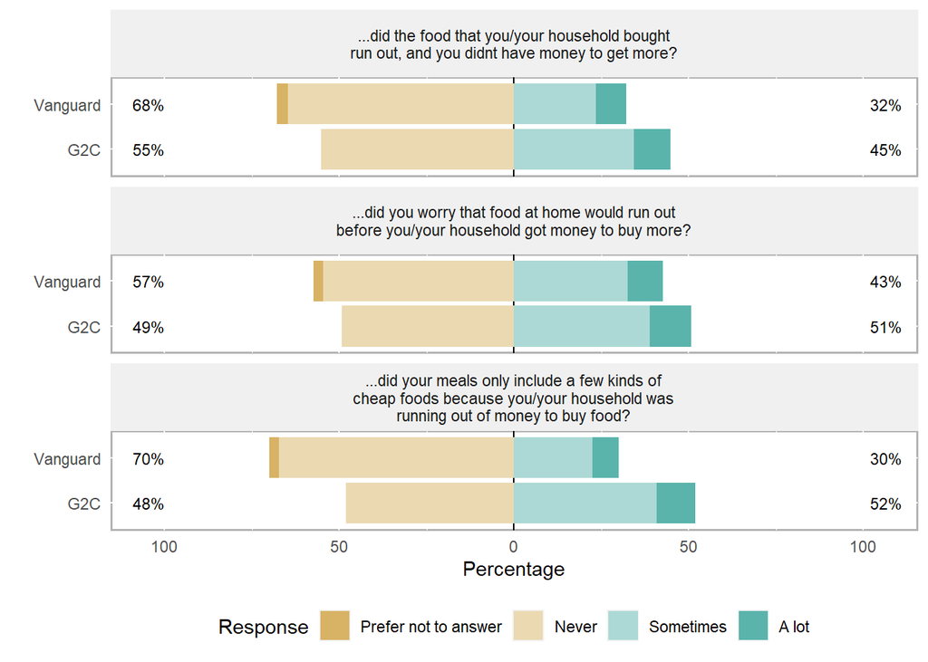

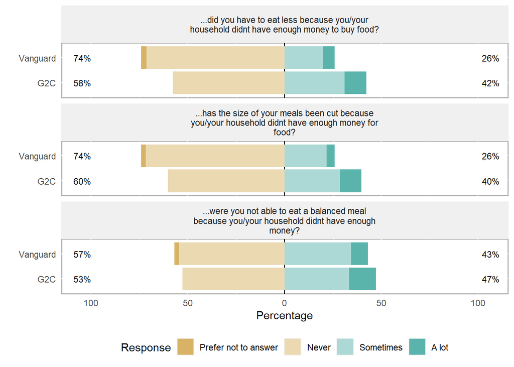

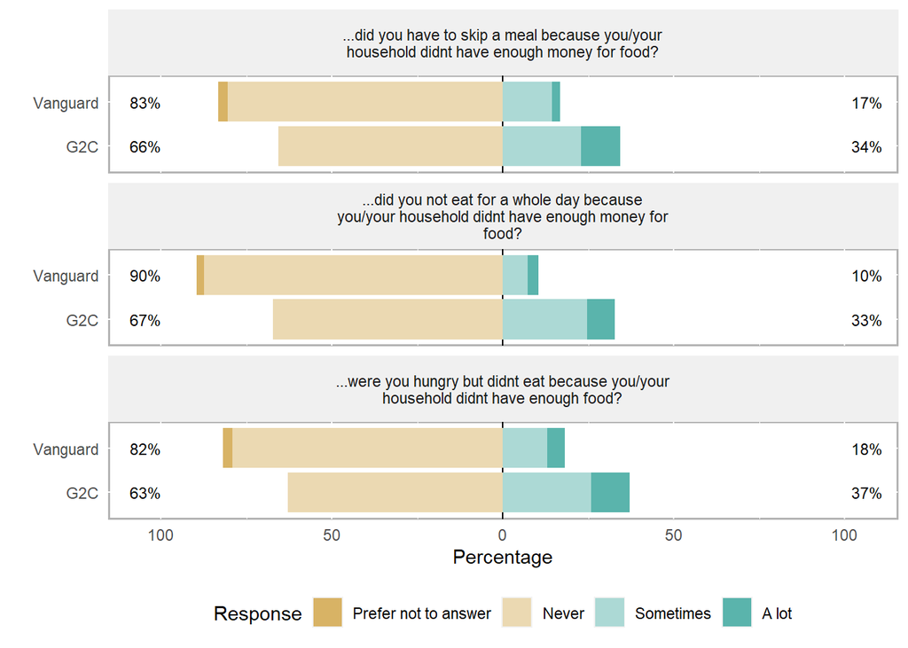

**Histogram of Food Security Scores (total of 9 variables, range:0-18): Vanguard vs. G2C**

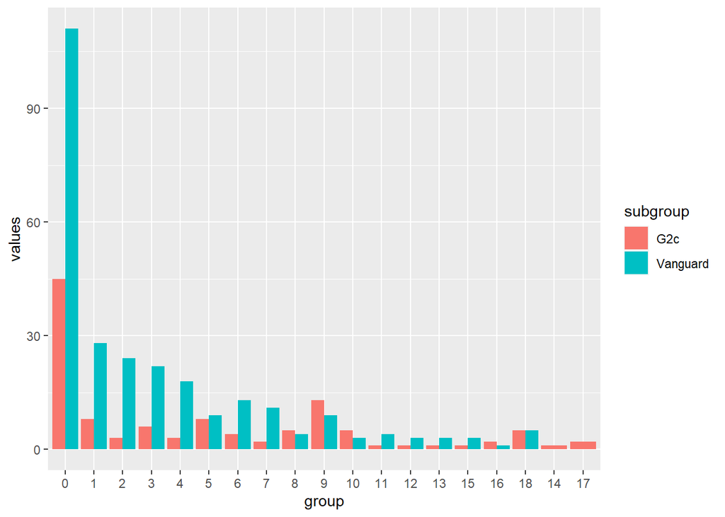

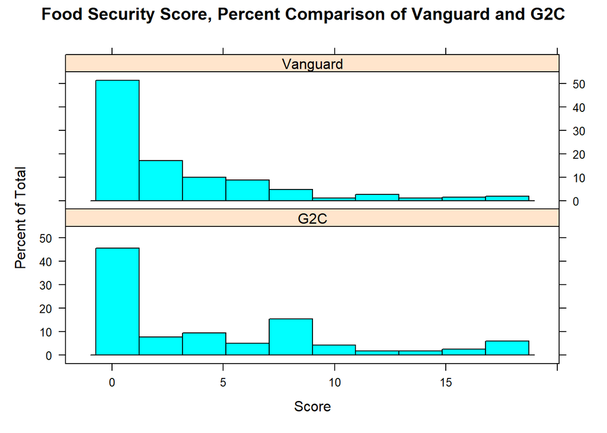

```
##
##  Wilcoxon rank sum test with continuity correction
##
## data:  food_total_merged$food_total_no_refused by food_total_merged$study
## W = 17896, p-value = 0.02534
## alternative hypothesis: true location shift is not equal to 0
```

```
##
##  Welch Two Sample t-test
##
## data:  food_total_merged$food_total_no_refused by food_total_merged$study
## t = 3.0011, df = 174.02, p-value = 0.003085
## alternative hypothesis: true difference in means between group G2C and group Vanguard is not equal to 0
## 95 percent confidence interval:
##  0.5784812 2.8009564
## sample estimates:
##      mean in group G2C mean in group Vanguard
##               4.741379               3.051661
```

Food Security Score comparison

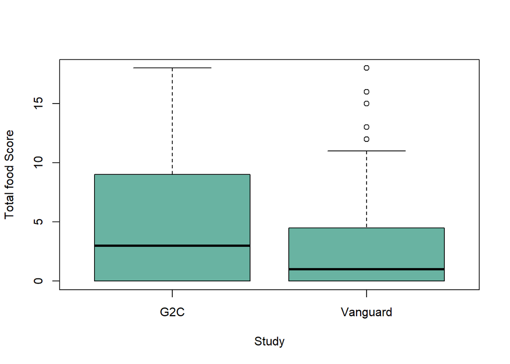